LXG

Above and Beyond.

# 曲线族的过程控制

Xinguang Liu

2017年2月11日

## 标题来源

前几天一位化工业界的朋友讨论到如何对一组曲线做过程控制，某些工艺过程中在一个周期内采集/监测的信号是一些随时间非线性变化的值，简单来说就是一条非线性曲线。之前常说的过程控制SPC图都是基于线性模型的，通过组内组间的均值和方差，来演绎过程的稳定性。非线性的稳定性判定则需要基于自身的非线性关系，分析一组曲线的分布，类似与模型中的预测置信区间概念。

## 样例数据

### 单一曲线

某一个周期内采集到的信号：

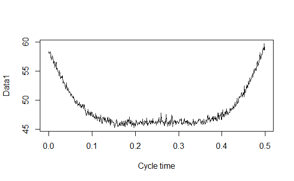

对曲线做光滑拟合

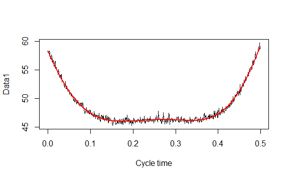

### 曲线族

某段时间间隔内采集到的所有信号：

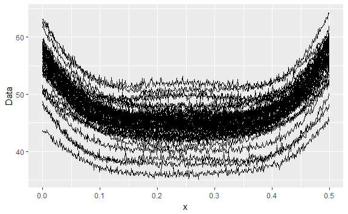

### 过程稳定分析

跟常规SPC一样，过程数据分为两个步骤：

- Phase 1, 分析阶段，在一个既定时间段内分析过程稳定时的数据分布、分布特征参数和稳定性阈值；
- Phase 2, 控制阶段，基于第一阶段的数据分布和阈值，对后续新的数据点进行监测控制。

#### Phase 1

以过程前期的35个信号为基础，分析过程数据分布特征：

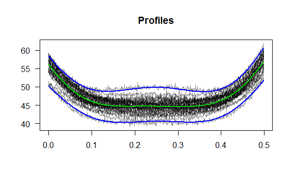

如果在`Phase 1`中有异常值，则分析导致异常的因素（特殊原因）并修正，之后剔除该点数据，重新计算分布参数和控制阈值，目的是找出过程稳定时应该具备的特征，如果后续过程无变动，则该分布特征应该得到延续，这是假设检验的原命题`H0`。

#### Phase 2

基于已得出的阈值对后续新数据点进行控制：

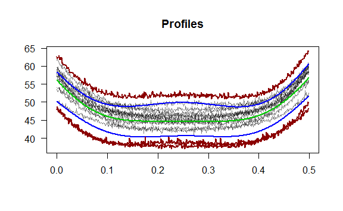

异常点标号：

```
#> [1] "P46" "P47" "P48"
```

异常点信号：

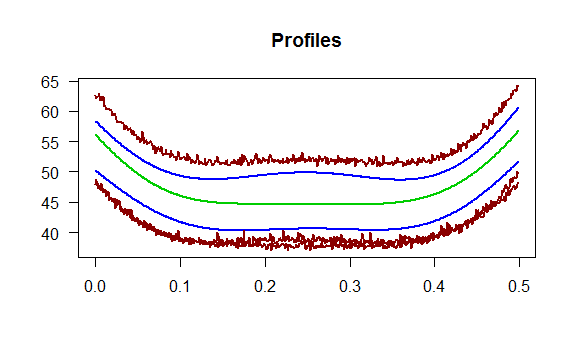

## 小结

关于非线性数据剖面的过程控制已有很多论文，在标准文件[ISO 11843-5:2008](http://www.iso.org/iso/catalogue_detail.htm?csnumber=42000)也有讨论，方法也不止一个，具体应用需要根据业务场景来进行选择和调配。